# HW1

SamG

February 22, 2019

question 1 MarioKart (Wii) w/ wheel is the title of the least expensive Mariokart game that included at least 1 sterring wheel in the ebay auction

```r
library(tidyverse)
library(openintro)
data <- marioKart %>%
  mutate(has.wheels = ifelse(wheels > 0,
                              1,
                              0)) %>%
  filter(has.wheels >0) %>%
  arrange(totalPr)
```

Question 2 The largest range in shipping price is the parcel shipping method, and the smallest is the UPS 3day.

```r
data <- marioKart %>%
  group_by(shipSp) %>%
  summarize(max.price = max(shipPr),
            min.price = min(shipPr)) %>%
  mutate(range = max.price - min.price)




data
```

```
## # A tibble: 8 x 4
##   shipSp     max.price min.price range
##   <fct>          <dbl>     <dbl> <dbl>
## 1 firstClass       4           0   4
## 2 media            4           0   4
## 3 other            4           0   4
## 4 parcel          25.5         0  25.5
## 5 priority        10.4         0  10.4
## 6 standard         4           0   4
## 7 ups3Day          4           4   0
## 8 upsGround       11.4         0  11.4
```

Q3 The median price of used marioKart games is $42.8, the mean is $47.1. The median price for new games is $54 and the mean is $53.8. I imagine this could be because of a few very high priced games driving up the mean price of used games, like rare of collectible games.

```r
data <- marioKart %>%
  group_by(cond) %>%
  summarize(mean.price = mean(totalPr),
             median.price = median(totalPr))
data
```

```
## # A tibble: 2 x 3
##   cond  mean.price median.price
##   <fct>      <dbl>        <dbl>
## 1 new         53.8         54.0
## 2 used        47.1         42.8
```

```r
data <- marioKart %>%
  group_by(cond) %>%
  summarize(max.price = max(totalPr),
            median.price = median(totalPr))
data
```

```
## # A tibble: 2 x 3
##   cond  max.price median.price
##   <fct>     <dbl>        <dbl>
## 1 new         75          54.0
## 2 used       327.         42.8
```

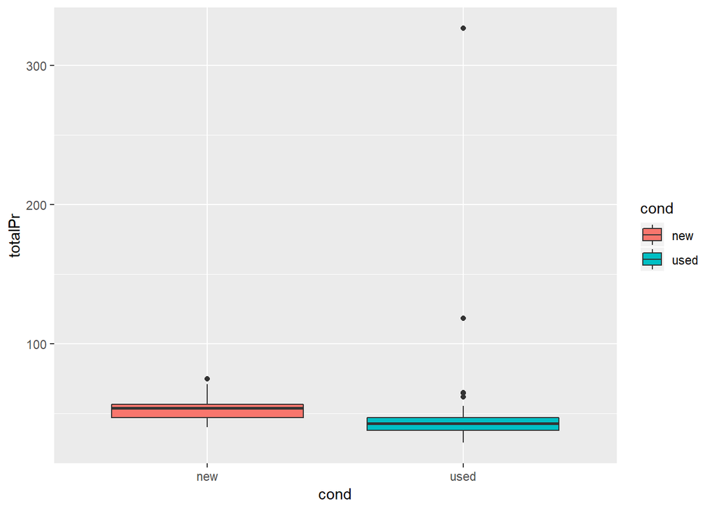

```r
marioKart %>%
  ggplot(mapping = aes(x = cond,
             y = totalPr)) +
  geom_boxplot(aes(fill = cond))
```

```r
data <-marioKart %>%
  arrange(-totalPr) %>%
  filter(totalPr < 76) %>%
  group_by(cond) %>%
  summarize(mean.price = mean(totalPr),
             median.price = median(totalPr))

data
```

```
## # A tibble: 2 x 3
##   cond  mean.price median.price
##   <fct>      <dbl>        <dbl>
## 1 new         53.8         54.0
## 2 used        42.9         42.4
```

Q6

Median price for used games with any number of wheels: $45.75 Median price for new games with any number of wheels: $53.99 Median price for used games without any wheels: $38.06 Median price for new games without any wheels: $47.38

```r
data <- marioKart %>%
  mutate(has.wheels = ifelse(wheels > 0,
                             1,
                             0)) %>%
  group_by(has.wheels, cond) %>%
  summarize(median.price = median(totalPr))
data
```

```
## # A tibble: 4 x 3
## # Groups:   has.wheels [2]
##   has.wheels cond  median.price
##        <dbl> <fct>        <dbl>
## 1          0 new           47.4
## 2          0 used          38.1
## 3          1 new           54.0
## 4          1 used          45.8
```

Q7 ProPortion of used games i’d be able to afford with $50: .85 proportion of new games I’d be able to afford with $50: .36

```r
data <- marioKart %>%
  group_by(cond) %>%
  mutate(below_50 = ifelse(totalPr <50,
                           1,
                           0)) %>%
  mutate(totalnumbers = ifelse(totalPr >= 0, 1,0)) %>%
  summarize(sum.below_50 = sum(below_50), #gets sums of those columns
            sum.totalnumbers = sum(totalnumbers))

data$porps <- data$sum.below_50 / data$sum.totalnumbers
data
```

```
## # A tibble: 2 x 4
##   cond  sum.below_50 sum.totalnumbers porps
##   <fct>        <dbl>            <dbl> <dbl>
## 1 new             21               59 0.356
## 2 used            71               84 0.845
```

Q8 Generally speaking, new games seemingly have higher ending prices than used ones, with the exception of the two large outliers. It seems like games with stock photos have a bit higher ending price than those without, but not that much of a difference. It is also important to note that we can’t have more confidence in these observations without appropriate statistical tests, and also that the two outliers from the used games may lead to interpretations that might be somewhat different if the graphic was represented differntly.

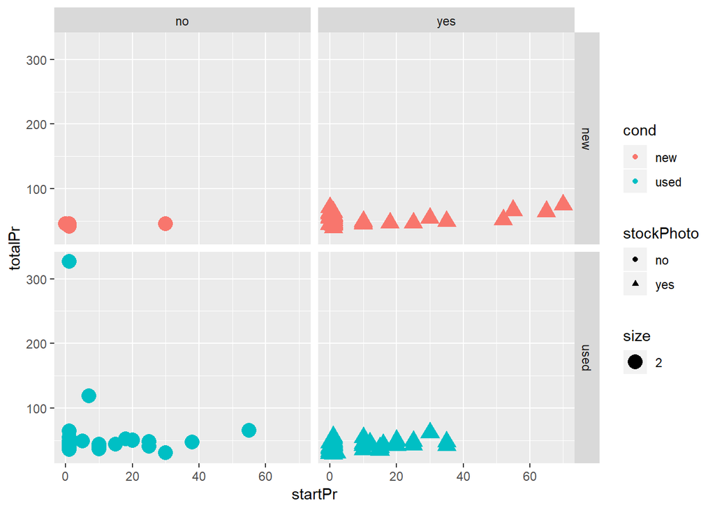

```r
marioKart %>%
  ggplot(aes(x= startPr,
             y = totalPr)) +
  geom_point(aes(color = cond, shape = stockPhoto, size = 2))+
  facet_grid(vars(cond), vars(stockPhoto))
```

Q9 I would first want my game to be new.

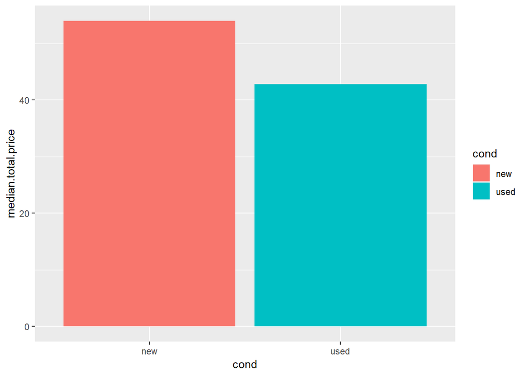

```r
marioKart %>%
  group_by(cond) %>%
  summarize(median.total.price = median(totalPr)) %>%
  ggplot(aes(x= cond, median.total.price,

             y = median.total.price)) +
  geom_col(aes(fill = cond))
```

I would also want to ship by either media or UPS ground, since those are the msot expensive shipping methods

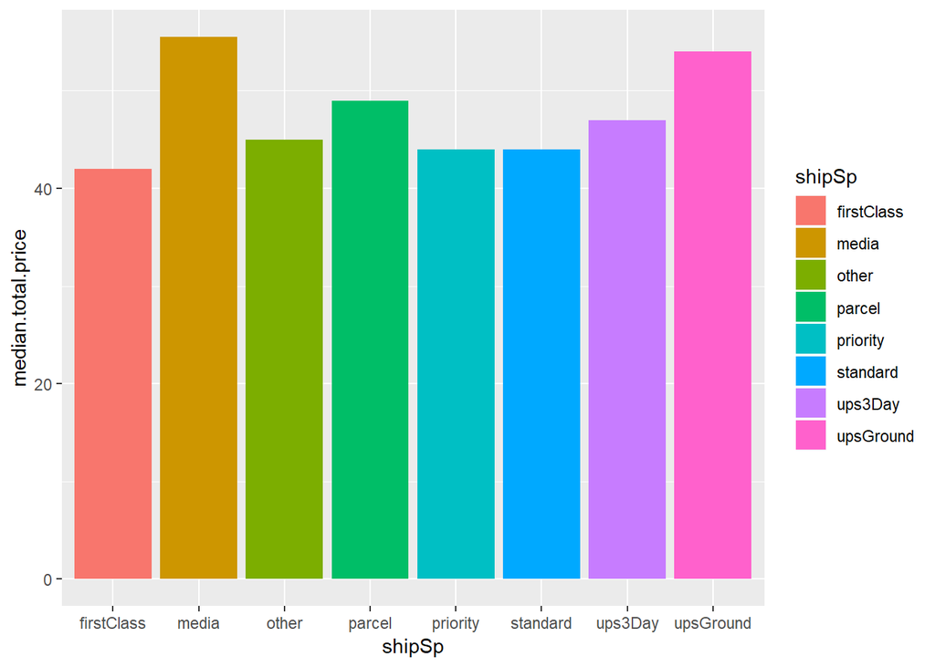

```r
marioKart %>%
  group_by(shipSp) %>%
  summarize(median.total.price = median(totalPr)) %>%
  ggplot(aes(x= shipSp, median.total.price,

             y = median.total.price)) +
  geom_col(aes(fill = shipSp))
```

I would want my game to have either 3 or 4 wheels (there was only 1 game that had 4 wheels so we can’t say that I don’t NOT want a 4 wheeled game)

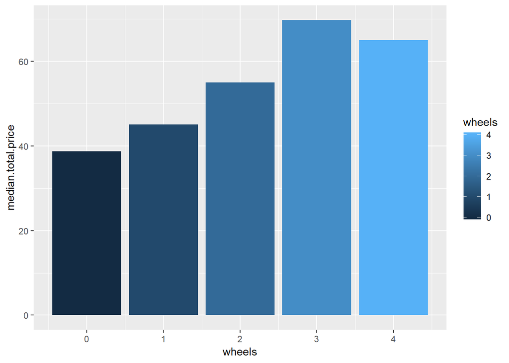

```r
marioKart %>%
  group_by(wheels) %>%
  summarize(median.total.price = median(totalPr)) %>%
  ggplot(aes(x= wheels, median.total.price,

             y = median.total.price)) +
  geom_col(aes(fill = wheels))
```

I would also use a stock photo

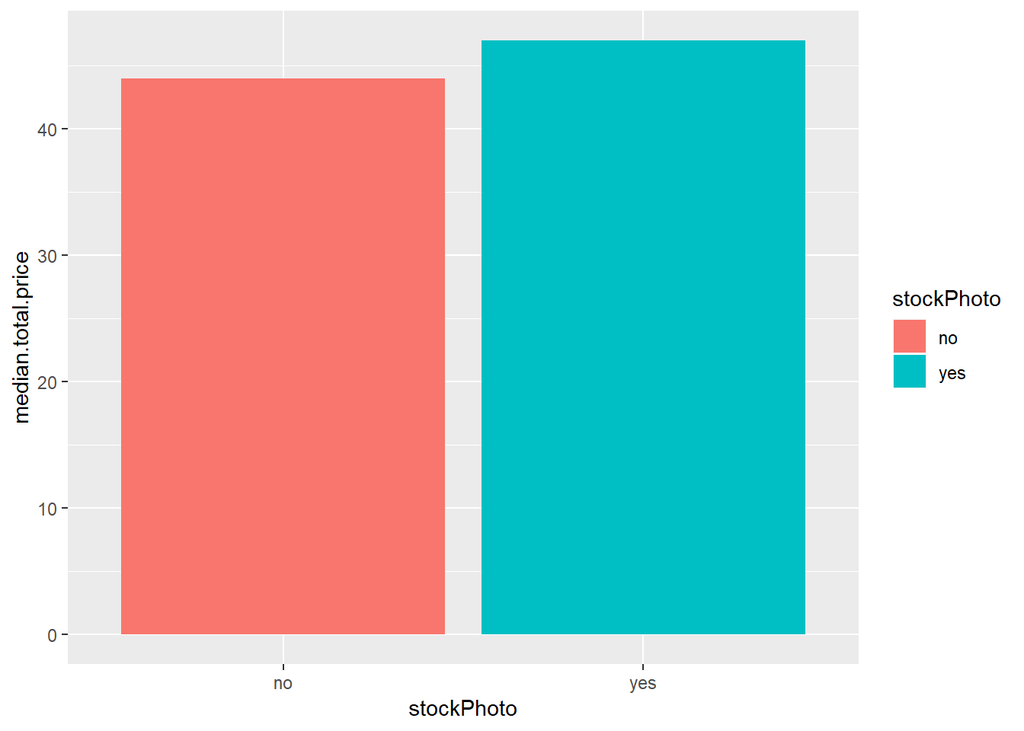

```r
marioKart %>%
  group_by(stockPhoto) %>%
  summarize(median.total.price = median(totalPr)) %>%
  ggplot(aes(x= stockPhoto, median.total.price,

             y = median.total.price)) +
  geom_col(aes(fill = stockPhoto))
```

So to sum, I would list a new game with a higher number of wheels, use a stock photo, and ship with a media or UPSground shipping method. Seller rating, duration, and number of bids didn’t particularly seems correlated with a higher total price.